# Jail

WeiXiao Sun

2/24/2022

# Introduction

Nowadays, the entire United States are facing the racial inequality of law. As we have the incarceration data collected by the Vera Institute, we are able to explore how the situation changed with time and whether the situation is getting better in recent years.To exclude the missing value and discover recent trends, I chose to study the data generated from 2010 to 2018.

```r
library(tidyverse)
#dataset
raw_data <- read.csv("incarceration_trends_preded.csv")
#I exclude some variables from downloaded file, and only focus on the time peroid 2010-2018
new_data <- raw_data %>% filter(year>=2010) %>% filter(year<=2018)
```

**code name** : Jail

**Project Title** : Incarceration Trends

**Authors** : WeiXiao Sun

**Affiliation** : INFO-201: Technical Foundations of Informathics - The Information School - University of Washington

**Date** : 2/24/2022

## Summary Information

```r
num_observations <- nrow(new_data)
num_variables <- ncol(new_data)
max_black_jail_pop_2018 <- new_data %>%
  filter(year == "2018") %>%
  select(black_jail_pop) %>%
  max(na.rm = TRUE)
max_white_jail_pop_2018 <- new_data %>%
  filter(year == "2018") %>%
  select(white_jail_pop) %>%
  max(na.rm = TRUE)
max_total_jail_pop_2018 <- new_data %>%
  filter(year == "2018") %>%
  select(total_jail_pop) %>%
  max(na.rm = TRUE)
max_total_jail_adm_2018 <- new_data %>%
  filter(year == "2018") %>%
  select(total_jail_adm) %>%
  max(na.rm = TRUE)
```

I focused primarily on the “incarcerated population” and “incarceration rate” by race, as well as their rates. The analysis of the prison population and prison admissions by race allows us to know the current racial population incarceration in US prisons. From there, we can infer the extent and trends of the independent variables on the dependent variable, and thus calculate the impact that racial demographic components have on the U.S. prison system. By analysing this data, we can determine the extent to which multiple factors influence incarceration in the United States. By analysing specific data, we can relate this situation to complex social and political structures in the pursuit of social justice in the true sense of the word.

## Table

### What are the top 10 counties had the highest total jail admissions rate from 2010-2018?

As recent year top 10 counties had highest average total jail admissions rates. This represents the number (rate) of times people are sent to prison from each county. Obviously, `Dickens County` should be more careful about putting people in prison and develop a robust system of law.

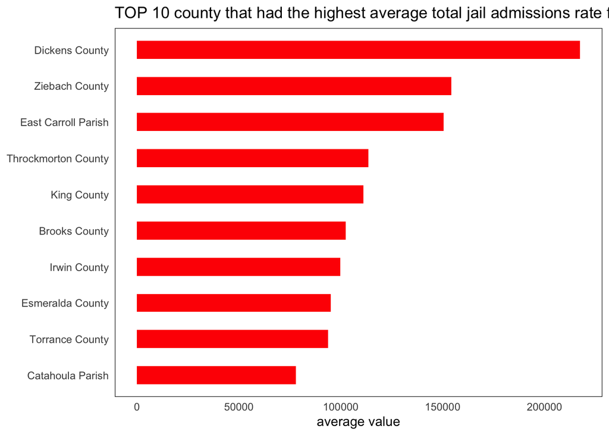

```r
library(ggthemes)
tja <- new_data %>% filter(year>=2010)  %>%
  group_by(county_name) %>%
  summarise(
    Totaladmissions=mean(total_jail_adm_rate,na.rm=T),
  ) %>%
  arrange(desc(Totaladmissions))
top10 <- tja[1:10,]

ggplot(top10) +
  geom_bar(aes(x= Totaladmissions,y = reorder(county_name, Totaladmissions)), width=0.5,stat='identity',fill="red") +
scale_y_discrete(position = "left")+
  theme_bw(base_line_size = 0) +
  labs(title= "TOP 10 county that had the highest average total jail admissions rate from 2010-2018",y = NULL,x="average value")
```

## Trends over time chart

### How the jail population by race changed from 2010 to 2018 in Dickens county.?

**Purpose:** Line Graph: Line graphs are used to track changes in data over time. Line charts can also be used to compare changes in multiple groups over the same time period.

**Insight:** It was created to inform trends over time in Dickens County’s racially diverse jail population from 2010 to 2018. This line graph allows us to see how the black, white, and Latino jail populations are trending compared to each other and to see how the jail population by race has changed from 2010 to 2018.

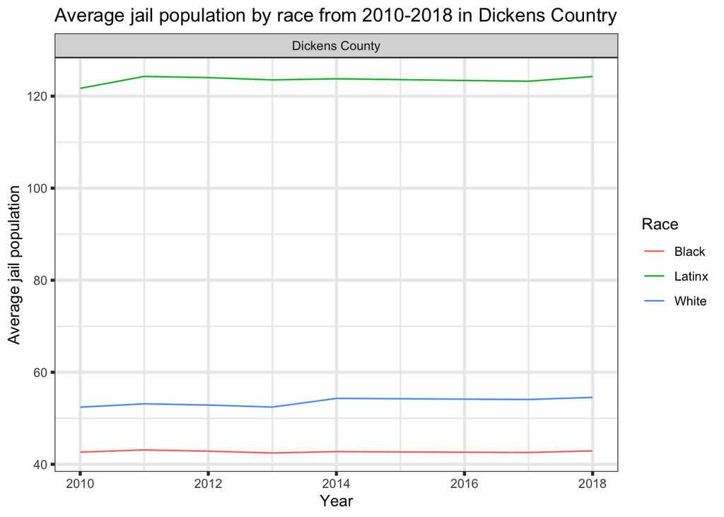

```r
library(reshape2)
Rp <- new_data %>% filter(county_name=="Dickens County")  %>% group_by(county_name,year) %>% summarise(
  Black=mean(black_jail_pop,na.rm=TRUE),
  Latinx=mean(latinx_jail_pop,na.rm=TRUE),
  White=mean(white_jail_pop,na.rm=TRUE)
) %>% melt(
  id.vars=c("county_name","year"),
  variable.name="Race",
  value.name="rjp"
)
ggplot(Rp) + geom_line(aes(x = year, y =rjp,color=Race))+ facet_wrap(~county_name)+
  theme_bw(base_line_size = 1) +
  labs(title= "Average jail population by race from 2010-2018 in Dickens Country",y = "Average jail population",x="Year")
```

## Variable comparison chart

### How average jail population and jail admission are related?

**Purpose:** Line Graph: Line graphs are used to track changes in data over time. Line charts can also be used to compare changes in multiple groups over the same time period.

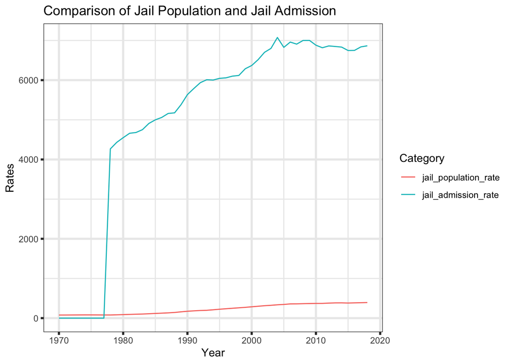

```r
Compare <- raw_data %>% group_by(year) %>% summarise(
  jail_population_rate=median(total_jail_pop_rate,na.rm=TRUE),
  jail_admission_rate=median(total_jail_adm_rate,na.rm=TRUE))
Compare1 <- Compare %>%melt(
  id.vars="year",
  variable.name="Category",
  value.name="Value"
)
ggplot(Compare1) + geom_line(aes(x = year, y =Value,color=Category))+
  theme_bw(base_line_size = 1) +
  labs(title= "Comparison of Jail Population and Jail Admission",y = "Rates",x="Year")
```

## Map

### What are the white and black people jail population count in 2018 over the U.S.?

**Purpose:** Choropleth Map: The Choropleth map is a thematic map that shows the extent to which summary statistics of interest are located, based on shades of colour.

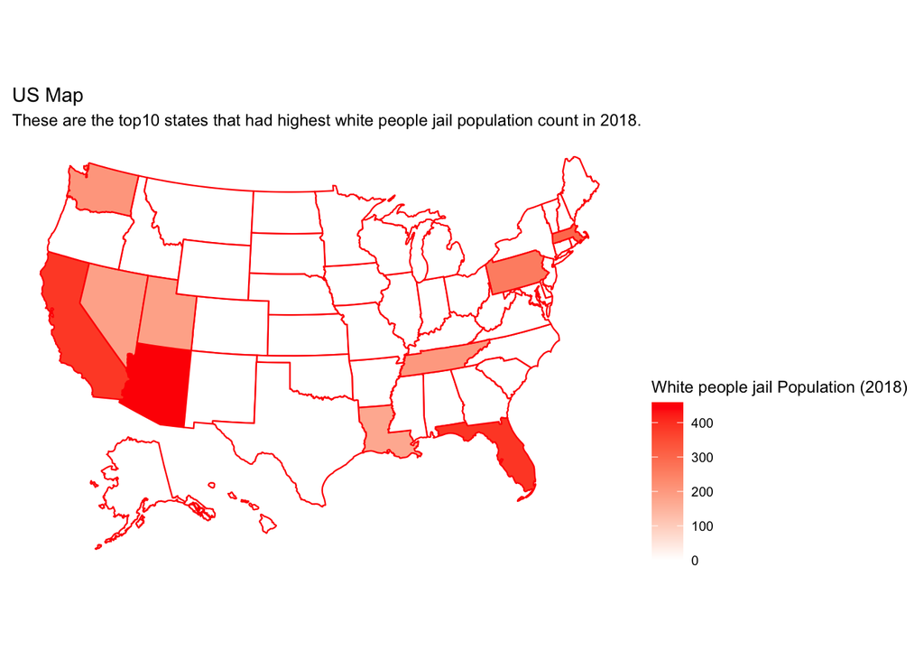

```r
library(usmap)
library(ggplot2)
usdatawhite2018 <- new_data %>% filter(year==2018) %>% group_by(state,year) %>% summarise(
  white_jail_pop=mean(white_jail_pop,na.rm=T)
  ) %>% arrange(desc(white_jail_pop))
usdatawhite2018 <- usdatawhite2018[1:10,]
#2018 map
usmapdata <-statepop
us2018 <- merge(usmapdata, usdatawhite2018, by.x = "abbr", by.y = "state",all.x=TRUE)
us2018[is.na(us2018)] <- 0
plot_usmap(
    data = us2018, values = "white_jail_pop", color = "red") +
  scale_fill_continuous(
    low = "white", high = "red", name = "White people jail Population (2018)", label = scales::comma
  ) +
  labs(title = "US Map", subtitle = "These are the top10 states that had highest white people jail population count in 2018.") +
  theme(legend.position = "right")
```

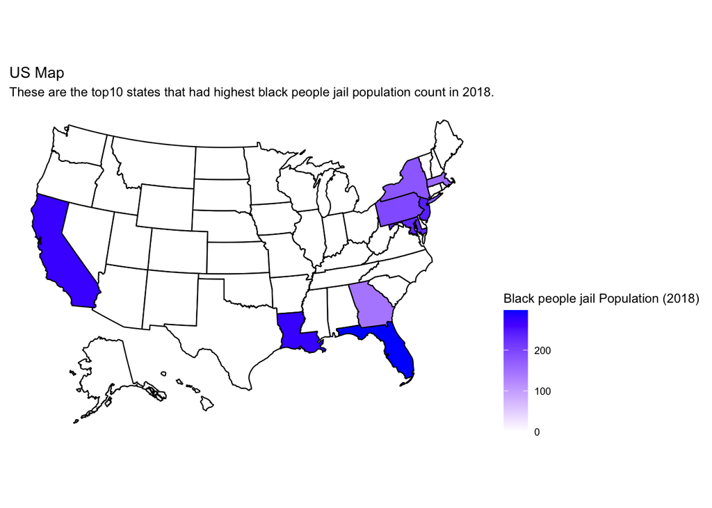

```r
usdatablack2018 <- new_data %>% filter(year==2018) %>% group_by(state,year) %>% summarise(
  black_jail_pop=mean(black_jail_pop,na.rm=T)
  ) %>% arrange(desc(black_jail_pop))

usdatablack2018 <- usdatablack2018[2:10,] #top is DC with 1774 we remove it
us2018 <- merge(usmapdata, usdatablack2018, by.x = "abbr", by.y = "state",all.x=TRUE)
us2018[is.na(us2018)] <- 0
plot_usmap(
    data = us2018, values = "black_jail_pop", color = "black") +
  scale_fill_continuous(
    low = "white", high = "blue", name = "Black people jail Population (2018)", label = scales::comma
  ) +
  labs(title = "US Map", subtitle = "These are the top10 states that had highest black people jail population count in 2018.") +
  theme(legend.position = "right")
```